# Jacksonville Wards Analysis

Ray Thompson

6/19/2020

# Introduction

The purpose of this document is to generate voter statistics on the first ward of Jacksonville, North Carolina. The first half covers general demographics of registered voters. Then an analysis of voting history from elections in the last 10 years. Lastly, I display useful subsets for political campaigns.

### Data

The datasets used in this analysis is public information obtained from the North Carolina [State Board Of Elections website](https://dl.ncsbe.gov/). Below is a list of the columns for the voter and voter history data set.

```
## Rows: 123,731
## Columns: 49
## $ county_id                <int> 67, 67, 67, 67, 67, 67, 67, 67, 67, 67, 67, …
## $ county_desc              <fct> ONSLOW, ONSLOW, ONSLOW, ONSLOW, ONSLOW, ONSL…
## $ voter_reg_num            <int> 357175, 369735, 445264, 461549, 449559, 4554…
## $ status_cd                <fct> A, R, I, A, I, A, I, A, A, A, A, I, A, I, D,…
## $ voter_status_desc        <fct> ACTIVE, REMOVED, INACTIVE, ACTIVE, INACTIVE,…
## $ reason_cd                <fct> AV, RL, IU, AV, IN, AV, IU, AV, AV, AV, AV, …
## $ voter_status_reason_desc <fct> VERIFIED, MOVED FROM COUNTY, CONFIRMATION RE…
## $ last_name                <fct> A'BRIAL, AAGAARD, AARON, AARON, AARON, AARON…
## $ first_name               <fct> BRUNO, TERESA, CORY, DAKOTA, DONAVON, HAYLEE…
## $ middle_name              <fct> NICKLOUS, INGRAM, BRAM, LEE, VINCENT, NICOLE…
## $ name_suffix_lbl          <fct> ,  , , , , , , , , , , , , , , , , , , , , ,…
## $ res_street_address       <fct> 609  WOLVERINE PL   , REMOVED, 4059  LILJA C…
## $ res_city_desc            <fct> JACKSONVILLE, , MIDWAY PARK, JACKSONVILLE, S…
```

[output cut: 36 more lines]

```
## Rows: 364,964
## Columns: 15
## $ county_id         <int> 67, 67, 67, 67, 67, 67, 67, 67, 67, 67, 67, 67, 67,…
## $ county_desc       <fct> ONSLOW, ONSLOW, ONSLOW, ONSLOW, ONSLOW, ONSLOW, ONS…
## $ voter_reg_num     <int> 480992, 480992, 480992, 480992, 480992, 480992, 478…
## $ election_lbl      <fct> 11/02/2010, 11/08/2016, 11/06/2018, 11/04/2014, 11/…
## $ election_desc     <fct> 11/02/2010 GENERAL, 11/08/2016 GENERAL, 11/06/2018 …
## $ voting_method     <fct> IN-PERSON, ABSENTEE ONESTOP, PROVISIONAL, IN-PERSON…
## $ voted_party_cd    <fct> UNA, UNA, REP, UNA, UNA, REP, DEM, DEM, DEM, DEM, D…
## $ voted_party_desc  <fct> UNAFFILIATED, UNAFFILIATED, REPUBLICAN, UNAFFILIATE…
## $ pct_label         <fct> 08S, 10N, 10N, 08S, 08S, EN03, 13, 13, 13, 13, 13, …
## $ pct_description   <fct> SOUTH NEWLIN, NORTH MELVILLE, NORTH MELVILLE, SOUTH…
## $ ncid              <fct> AA100682, AA100682, AA100682, AA100682, AA100682, A…
## $ voted_county_id   <int> 1, 1, 1, 1, 1, 67, 1, 1, 1, 1, 1, 1, 67, 67, 67, 67…
## $ voted_county_desc <fct> ALAMANCE, ALAMANCE, ALAMANCE, ALAMANCE, ALAMANCE, O…
## $ vtd_label         <fct> 08S, 10N, 10N, 08S, 08S, EN03, 13, 13, 13, 13, 13, …
## $ vtd_description   <fct> 08S, 10N, 10N, 08S, 08S, EN03, 13, 13, 13, 13, 13, …
```

The voter file provided by the NCSBE contains 123731 records of past and present voters. There is an average of 7778 records for each Ward. Ward 1 contains 3446 records.

# Ward Demographics

## Party

### Average age by party

```
## # A tibble: 6 x 2
##   party_cd Average.Age
##   <fct>          <dbl>
## 1 CST             29.8
## 2 DEM             47.2
## 3 GRE             43
## 4 LIB             31.7
## 5 REP             35.5
## 6 UNA             34.0
```

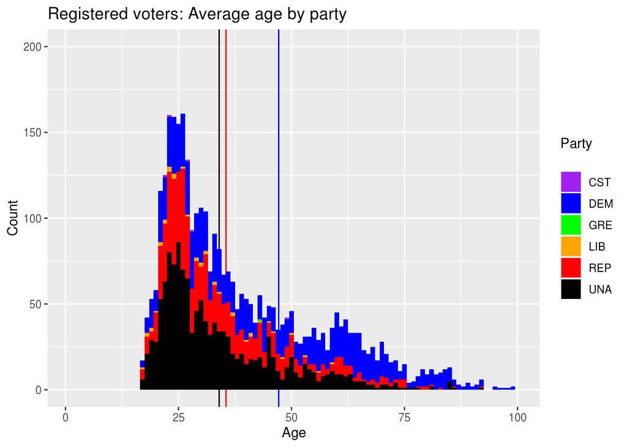

Unaffiliated voters comprise the largest chunk of registered voters and also have a lower mean age than Democrats and Republicans. Democrats are the second largest chunk with the highest mean age among all parties. Republicans are on average 12 years younger than democrats and 1.5 years older than unaffiliated voters.

### No. of voters by party

```
##  CST  DEM  GRE  LIB  REP  UNA
##    5 1211    1   40  862 1327
```

### No. of voters per age group

```
## 18-34 35-49 50-64   65+  NA's
##  1811   753   509   355    18
```

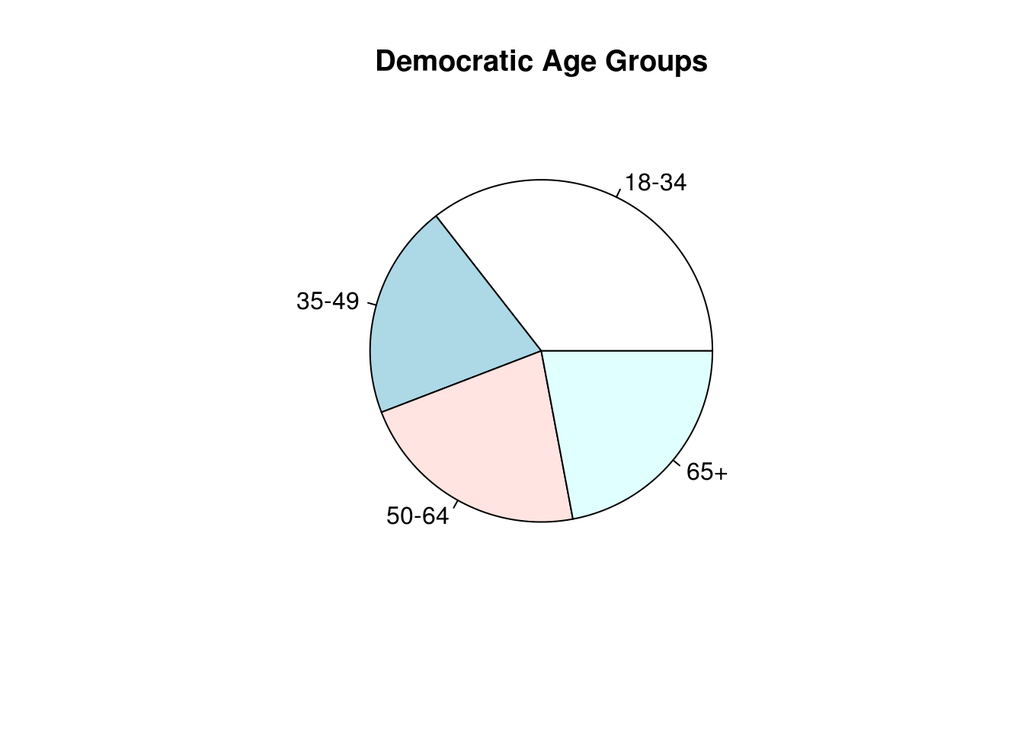

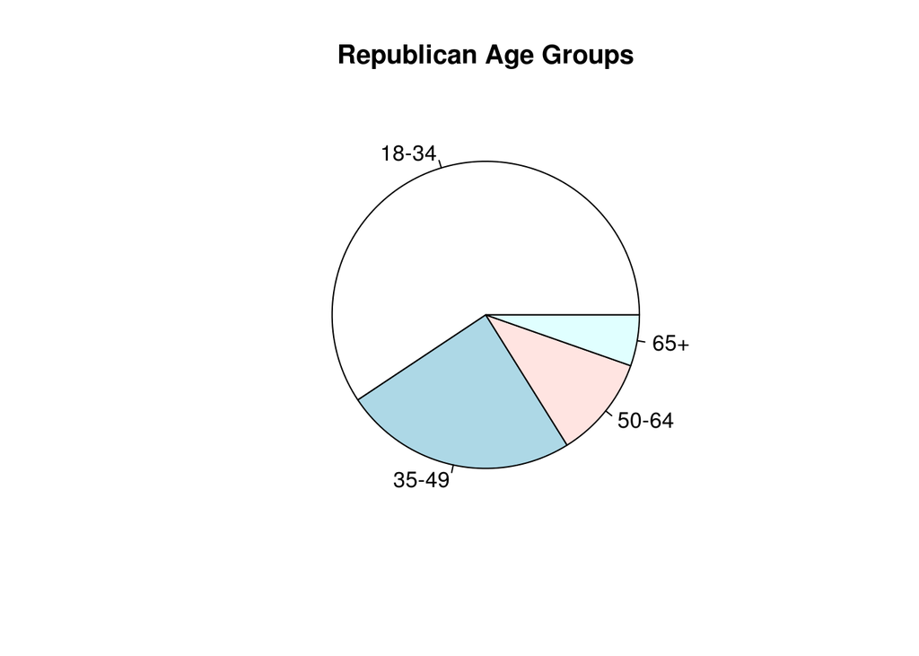

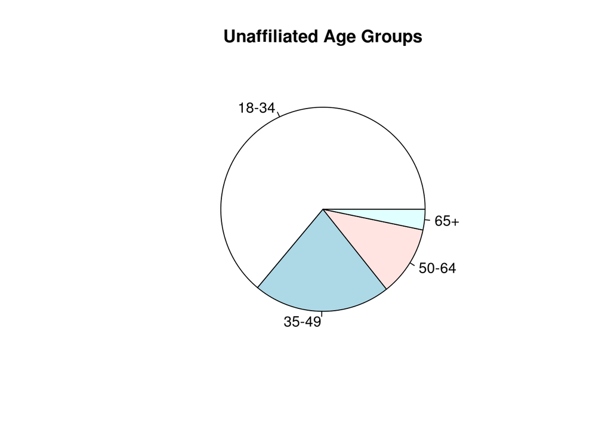

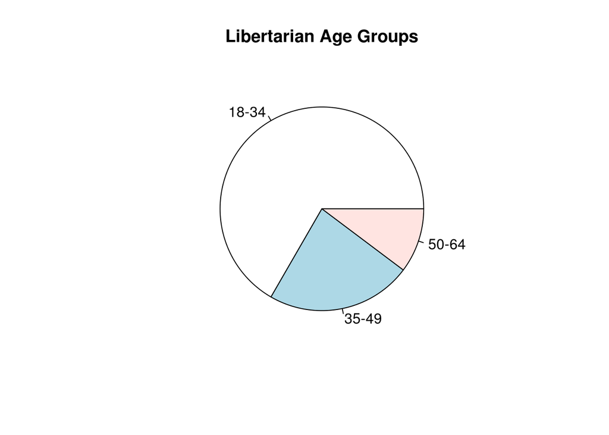

There are around 1700 more registered voters in the 18-49 demographic than people 50+. This is interesting because as you'll see in the Voter History section of this document , the 50+ demographic takes up a much larger share of the votes cast from 2010-2020.

### Distribution on Map

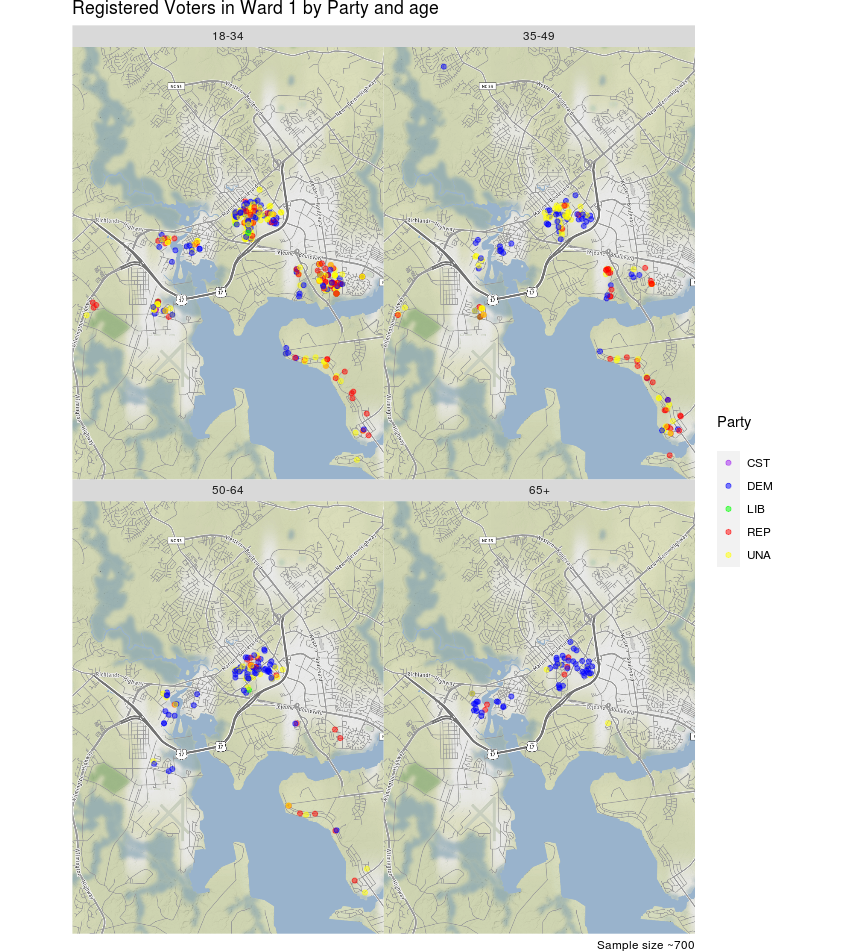

It appears that the first ward is comprised of 5-6 neighborhood with one being inside Camp Lejeune. The age group of 18-34 appears to be the most diverse in terms of party affiliation. There seems to be a trend of democrat affiliation the older an age group is. That does not seem to apply to the neighborhood in Camp Lejeune as the marines there are usually republican or unaffiliated.

### Party by Race

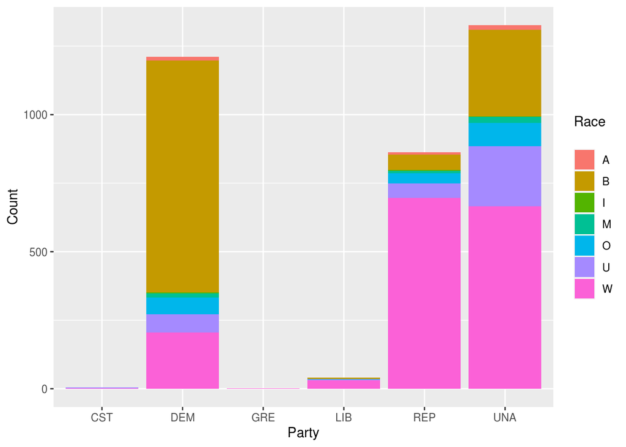

It's obvious that a majority of black people are either in the democratic party or are unaffiliated. There are over 1000 white republican and unaffiliated voters and under 250 white Democratic voters.

### Party by Sex

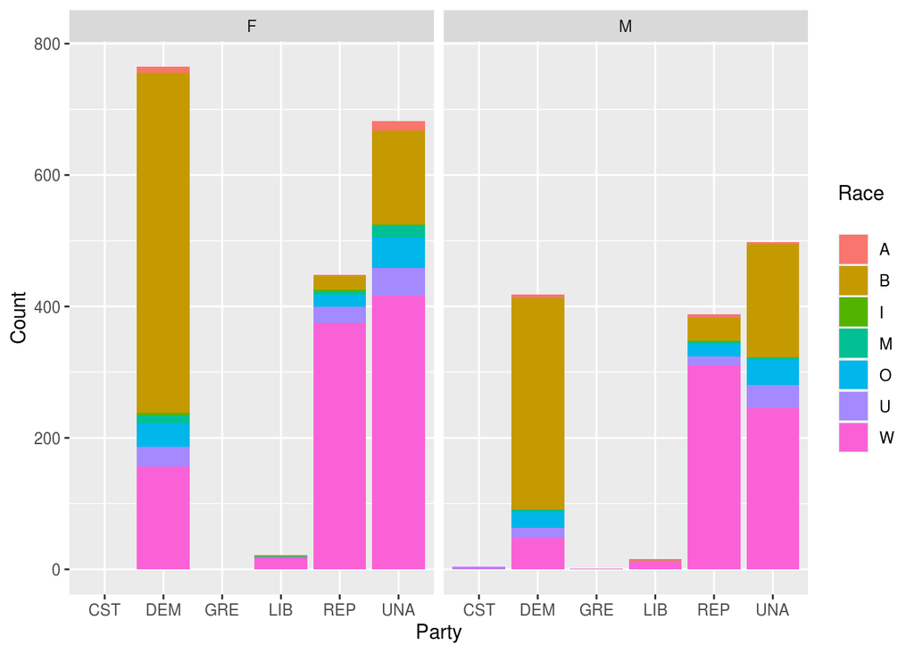

### No. of voters by gender

```
##    F    M    U
## 1917 1325  204
```

## Age

### Average Age by Race

```
## # A tibble: 7 x 2
##   race_code Average.Age
##   <fct>           <dbl>
## 1 A                37.2
## 2 B                46.2
## 3 I                36.4
## 4 M                32.4
## 5 O                34.4
## 6 U                35.6
## 7 W                34.9
```

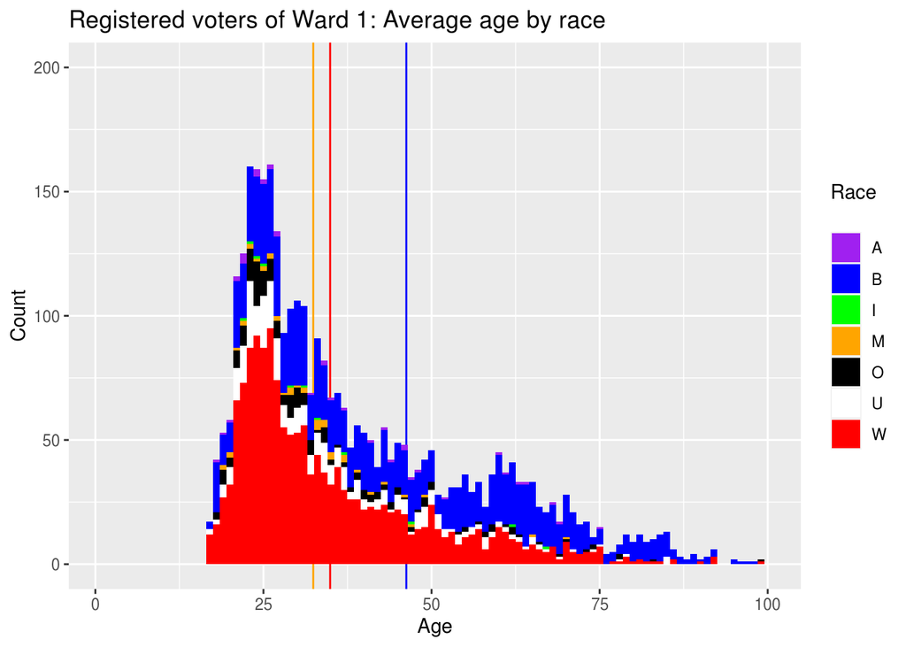

### No. of voters by Race

```
##    A    B    I    M    O    U    W
##   38 1222   11   44  187  343 1601
```

### Distribution on Map

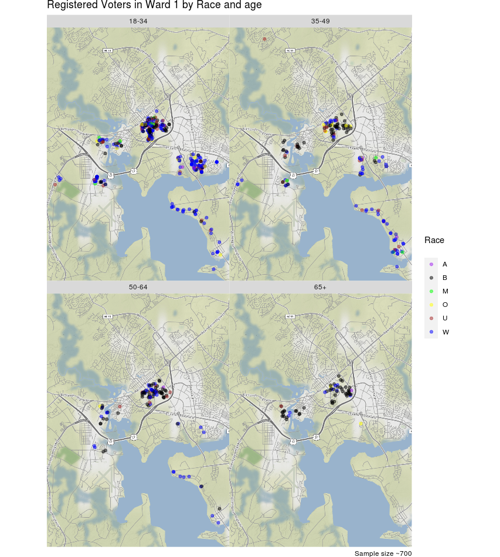

### Race and Sex

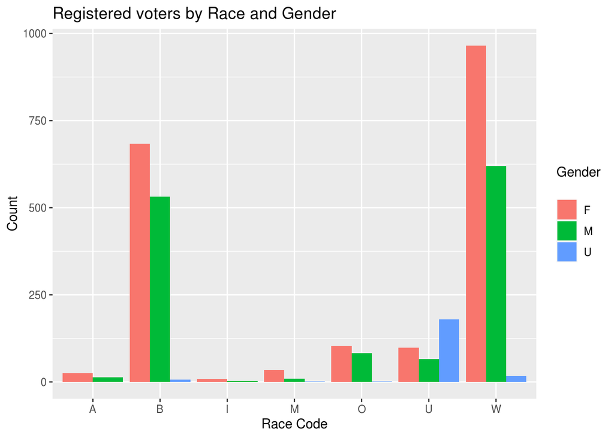

### Average Age by Sex

```
## # A tibble: 3 x 2
##   gender_code Average.age
##   <fct>             <dbl>
## 1 F                  39.3
## 2 M                  38.9
## 3 U                  36.4
```

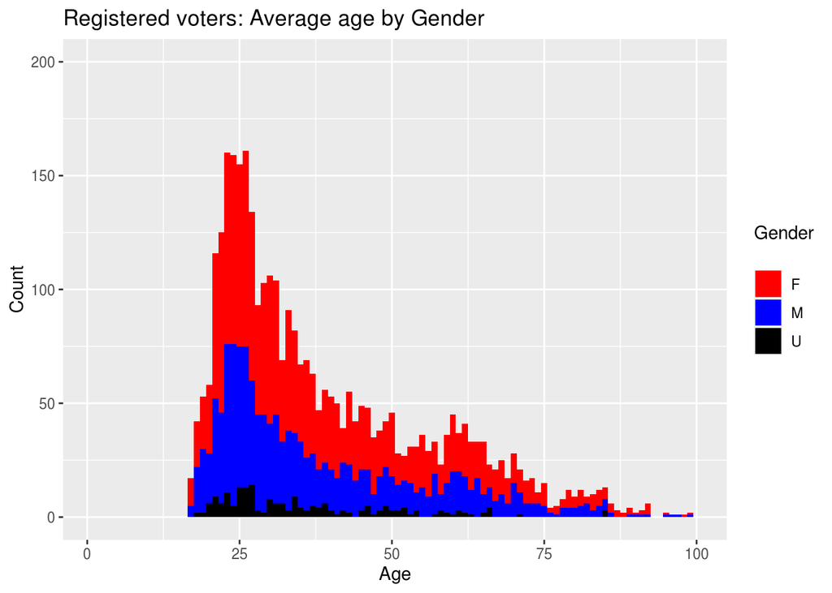

```
##    F    M    U
## 1917 1325  204
```

### General Age Summary

```
##    Min. 1st Qu.  Median    Mean 3rd Qu.    Max.
##   17.00   25.00   33.00   38.98   50.00  120.00
```

There are multiple 17 year old voters registered in preparation for the 2020 elections. The oldest person on the roll is 120 and he is listed as voting in 2016 in person. He is the only person on the roll above 100 and I'm not sure if it is an error.

# Voter History

## Registration

### Registrations by Year

```
##         Min.      1st Qu.       Median         Mean      3rd Qu.         Max.
## "1966-10-08" "1984-01-28" "2003-09-24" "1998-02-27" "2012-05-26" "2020-03-06"
```

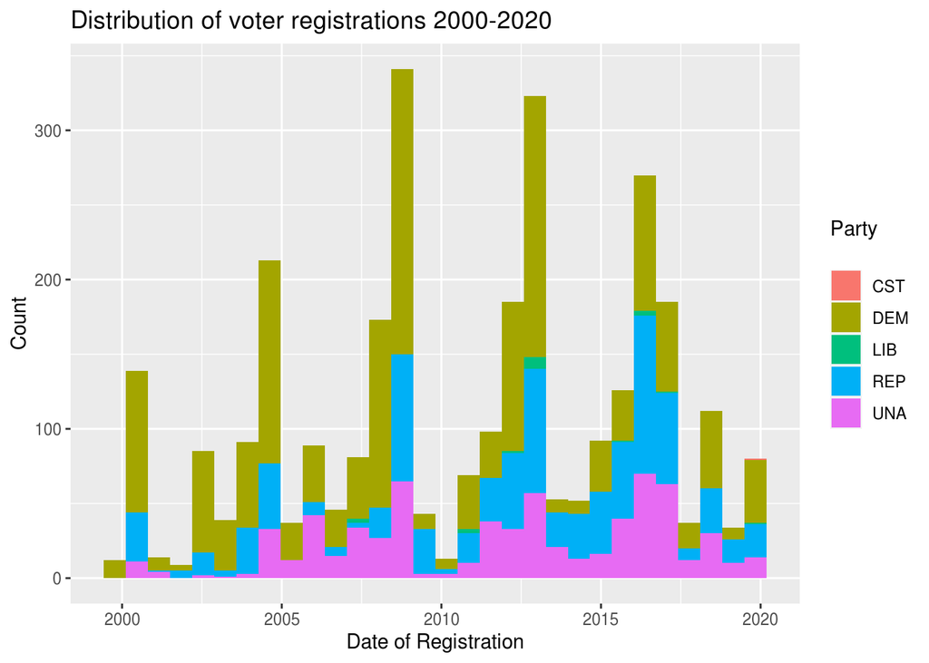

I believe the largest registration spikes are for the 2008, 2012, and 2016 elections. There are noticeably smaller spikes for the 2018 midterms and 2020 election.

## Elections

### Votes Cast by Age Group

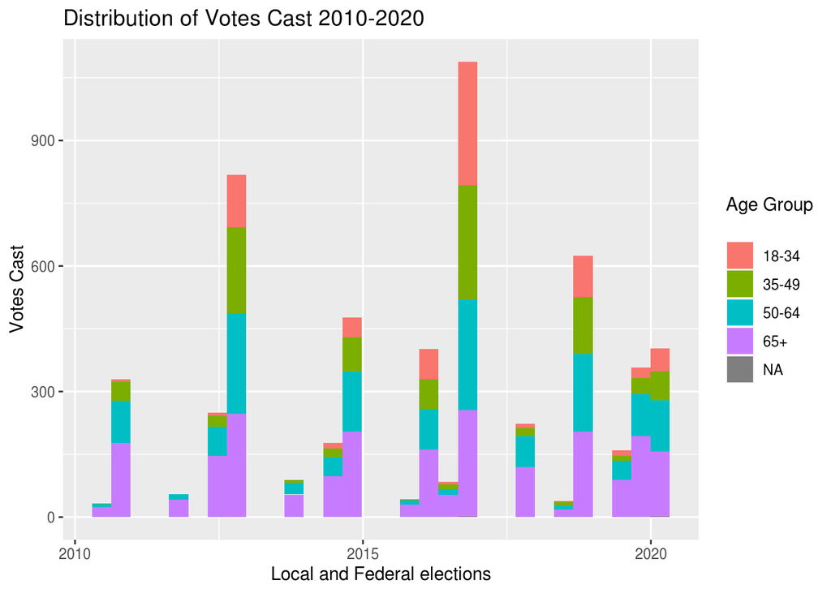

| election_desc | votes_cast |
| --- | --- |
| 11/08/2016 GENERAL | 1088 |
| 11/06/2012 GENERAL | 818 |
| 11/06/2018 GENERAL | 625 |
| 11/04/2014 GENERAL | 477 |
| 03/03/2020 PRIMARY | 403 |
| 03/15/2016 PRIMARY | 402 |
| 11/02/2010 GENERAL | 330 |
| 05/08/2012 PRIMARY | 232 |
| 11/07/2017 MUNICIPAL | 223 |
| 09/10/2019 GENERAL | 216 |

[output cut: 11 more lines]

The 50+ age group consistently votes more than ages 18-49 although the 2016 saw a roughly equal amount of both. The 2020 primary had a very low number of young voters even though they outnumber elderly voters and had multiple progressive candidates on the ballot.

# Voter Subsets

Examples of datasets that could be used by campaigns to target groups of voters.

## Party

#### Black Republican Males

```r
glimpse(group1)
```

```
## Rows: 35
## Columns: 10
## $ first_name         <fct> GYASI, JOSEPH, DEMONT TREY, SYLVESTER, RASHAD, DAS…
## $ last_name          <fct> ALLEN, BENSON, BLACKMON, COLE, COOPER, DELOACH, DI…
## $ birth_age          <int> 34, 28, 26, 61, 31, 33, 53, 18, 47, 25, 40, 30, 29…
## $ gender_code        <fct> M, M, M, M, M, M, M, M, M, M, M, M, M, M, M, M, M,…
## $ race_code          <fct> B, B, B, B, B, B, B, B, B, B, B, B, B, B, B, B, B,…
## $ party_cd           <fct> REP, REP, REP, REP, REP, REP, REP, REP, REP, REP, …
## $ full_phone_number  <dbl> 9104550435, 9103330657, 6015490590, 3374142192, 91…
## $ res_street_address <fct> 125  DARDEN ST   , 378  EASTWOOD DR   , 118  BROAD…
## $ res_city_desc      <fct> JACKSONVILLE, JACKSONVILLE, JACKSONVILLE, JACKSONV…
## $ zip_code           <int> 28540, 28540, 28540, 28540, 28540, 28540, 28540, 2…
```

35 voters

#### White Democrat Males

```r
glimpse(group2)
```

```
## Rows: 48
## Columns: 10
## $ first_name         <fct> KEVIN, MICHAEL, ANTHONY, BENJAMIN, JAMES, THOMAS, …
## $ last_name          <fct> ANDERSON, ASHLINE, AUGUSTA, BENTRUP, CALDWELL, CHA…
## $ birth_age          <int> 65, 39, 64, 64, 46, 44, 30, 56, 26, 24, 28, 25, 57…
## $ gender_code        <fct> M, M, M, M, M, M, M, M, M, M, M, M, M, M, M, M, M,…
## $ race_code          <fct> W, W, W, W, W, W, W, W, W, W, W, W, W, W, W, W, W,…
## $ party_cd           <fct> DEM, DEM, DEM, DEM, DEM, DEM, DEM, DEM, DEM, DEM, …
## $ full_phone_number  <dbl> 9103338069, 9105816533, 6037627293, 4554717, 91038…
## $ res_street_address <fct> 1711  HARGETT ST   #1B, 344  EASTWOOD DR   , 299  …
## $ res_city_desc      <fct> JACKSONVILLE, JACKSONVILLE, JACKSONVILLE, JACKSONV…
## $ zip_code           <int> 28540, 28540, 28540, 28540, 28540, 28540, 28540, 2…
```

48 voters

```r
glimpse(group3)
```

```
## Rows: 38
## Columns: 10
## $ first_name         <fct> MARIA JOANA, ADAM, SUPAWADEE, ALFONSO KEIFER, MAHE…
## $ last_name          <fct> ANDERSON, BELL, BUI, CACHA, CHINEN-MARCELLO, CHIU,…
## $ birth_age          <int> 43, 34, 20, 25, 21, 52, 61, 25, 37, 69, 63, 22, 27…
## $ gender_code        <fct> F, M, F, M, F, M, M, F, M, F, F, F, M, M, F, F, F,…
## $ race_code          <fct> A, A, A, A, A, A, A, A, A, A, A, A, A, A, A, A, A,…
## $ party_cd           <fct> UNA, REP, UNA, UNA, REP, REP, DEM, UNA, REP, DEM, …
## $ full_phone_number  <dbl> 8586102927, 2675055033, 7077544435, 9136992759, 70…
## $ res_street_address <fct> 6672  KALINOWSKI RD   , 101  BANKS ST   , 118  BRO…
## $ res_city_desc      <fct> TARAWA TERRACE, JACKSONVILLE, JACKSONVILLE, TARAWA…
## $ zip_code           <int> 28543, 28540, 28540, 28543, 28540, 28547, 28540, 2…
```

38 voters

#### Black Unaffiliated Females

```r
glimpse(group4)
```

```
## Rows: 143
## Columns: 10
## $ first_name         <fct> JUANITA, CHRISTNE, OGHENEOCHUKO, SHANTIL, KEELAH, …
## $ last_name          <fct> ADAMS, AGUIAE, AKPORE, ALLEN, AMER, AMINU, ANDERSO…
## $ birth_age          <int> 47, 37, 39, 29, 36, 41, 36, 63, 52, 28, 27, 40, 45…
## $ gender_code        <fct> F, F, F, F, F, F, F, F, F, F, F, F, F, F, F, F, F,…
## $ race_code          <fct> B, B, B, B, B, B, B, B, B, B, B, B, B, B, B, B, B,…
## $ party_cd           <fct> UNA, UNA, UNA, UNA, UNA, UNA, UNA, UNA, UNA, UNA, …
## $ full_phone_number  <dbl> 9102996344, NA, 9104780404, 9105651860, 9106362903…
## $ res_street_address <fct> 708  NEW RIVER DR   , 716  NEW RIVER DR   , 227  Y…
## $ res_city_desc      <fct> JACKSONVILLE, JACKSONVILLE, JACKSONVILLE, JACKSONV…
## $ zip_code           <int> 28540, 28540, 28540, 28540, 28540, 28540, 28540, 2…
```

143 voters

## Age

#### Democrats: Ages 18-34

```r
glimpse(group1)
```

```
## Rows: 433
## Columns: 10
## $ first_name         <fct> KRISTY, TAYLOR, TYRIQ, ASHAYLA, SUZAN, ATTIA, EDWA…
## $ last_name          <fct> ADAMS, ADDIS, AHMAD, AKPORE, ALKHATIB, ALLEXNE, AR…
## $ birth_age          <int> 34, 26, 19, 21, 29, 18, 31, 30, 29, 17, 24, 25, 21…
## $ gender_code        <fct> F, F, M, F, F, F, M, M, M, F, M, F, F, M, F, M, F,…
## $ race_code          <fct> U, W, B, B, O, B, B, B, B, B, B, B, B, B, W, B, W,…
## $ party_cd           <fct> DEM, DEM, DEM, DEM, DEM, DEM, DEM, DEM, DEM, DEM, …
## $ full_phone_number  <dbl> 5102847918, 9103306606, 8086700228, 9108034323, 91…
## $ res_street_address <fct> 2409  SAINT MARYS DR   , 1699  ROBINSON DR   , 664…
## $ res_city_desc      <fct> CAMP LEJEUNE, JACKSONVILLE, TARAWA TERRACE, JACKSO…
## $ zip_code           <int> 28547, 28540, 28543, 28540, 28540, 28540, 28540, 2…
```

433 voters

#### Democrat & Unaffiliated: Ages 34-49

```r
glimpse(group2)
```

```
## Rows: 532
## Columns: 10
## $ first_name         <fct> DANIELLE, MOHAMED, LORNA, FELYSHA, JUANITA, AUGUST…
## $ last_name          <fct> ABNEY, ABOUELNASR, ACEVEDO, ADAMS, ADAMS, ADDAE-ME…
## $ birth_age          <int> 40, 45, 35, 35, 47, 42, 40, 42, 37, 42, 44, 39, 48…
## $ gender_code        <fct> F, M, F, F, F, M, M, F, F, M, F, F, M, M, M, M, U,…
## $ race_code          <fct> B, O, U, B, B, B, B, O, B, W, B, B, B, B, B, M, U,…
## $ party_cd           <fct> DEM, UNA, UNA, DEM, UNA, UNA, DEM, UNA, UNA, UNA, …
## $ full_phone_number  <dbl> 8044905489, 9103827819, 9105819188, 9105814500, 91…
## $ res_street_address <fct> 325  LEONARD ST   , 291  EASTWOOD DR   , 314  STAR…
## $ res_city_desc      <fct> JACKSONVILLE, JACKSONVILLE, JACKSONVILLE, JACKSONV…
## $ zip_code           <int> 28540, 28540, 28540, 28540, 28540, 28540, 28540, 2…
```

532 voters

#### Black Democrats: Ages 50+

```r
glimpse(group3)
```

```
## Rows: 440
## Columns: 10
## $ first_name         <fct> DE BORAH, STANLEY, SEQUOIA, MARTHA, PAUL, CHARLES,…
## $ last_name          <fct> ADAMS, ADOLPHUS, ALDRIDGE, ALSTON, ARCHIE, ARNOLD,…
## $ birth_age          <int> 64, 72, 54, 72, 50, 71, 71, 67, 60, 69, 50, 79, 57…
## $ gender_code        <fct> F, M, F, F, M, M, F, F, F, M, F, F, F, M, F, F, F,…
## $ race_code          <fct> B, B, B, B, B, B, B, B, B, B, B, B, B, B, B, B, B,…
## $ party_cd           <fct> DEM, DEM, DEM, DEM, DEM, DEM, DEM, DEM, DEM, DEM, …
## $ full_phone_number  <dbl> 9103465051, 9103817591, 9102652335, 9109394226, 91…
## $ res_street_address <fct> 364  EASTWOOD DR   , 243  YORK ST   , 146  LAGUNA …
## $ res_city_desc      <fct> JACKSONVILLE, JACKSONVILLE, JACKSONVILLE, JACKSONV…
## $ zip_code           <int> 28540, 28540, 28540, 28540, 28543, 28540, 28540, 2…
```

440 voters

#### Minority Republicans: Ages 18-49

```r
glimpse(group4)
```

```
## Rows: 136
## Columns: 10
## $ first_name         <fct> TINA, KAILEEN, GYASI, NENA, REBECCA, ALANNA, APRIL…
## $ last_name          <fct> ADAMS, ADAMY-EDEN, ALLEN, ALLEN, ALOMAR, BAKER, BA…
## $ birth_age          <int> 47, 23, 34, 24, 37, 21, 45, 24, 27, 48, 23, 25, 35…
## $ gender_code        <fct> F, F, M, F, F, F, F, M, U, F, F, F, U, U, M, M, F,…
## $ race_code          <fct> B, U, B, O, U, O, U, O, U, U, M, U, M, U, A, B, O,…
## $ party_cd           <fct> REP, REP, REP, REP, REP, REP, REP, REP, REP, REP, …
## $ full_phone_number  <dbl> 9102996342, 3603502431, 9104550435, 5027092126, 57…
## $ res_street_address <fct> 708  NEW RIVER DR   , 6504  ALLEN LN   , 125  DARD…
## $ res_city_desc      <fct> JACKSONVILLE, TARAWA TERRACE, JACKSONVILLE, JACKSO…
## $ zip_code           <int> 28540, 28543, 28540, 28540, 28547, 28547, 28547, 2…
```

136 voters